# HW3

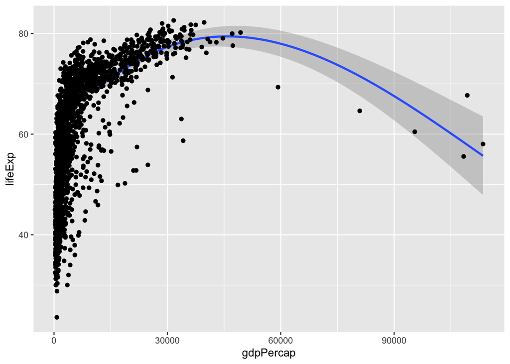

```r
p + geom_smooth() + geom_point()
```

- 2. Change the mappings in the *aes()* function so that you plot **life expectancy** against **population (pop)** rather than per capita GDP. What does that look like? What does it tell you about the unit of observation in the dataset? —The data is somewhat misrepresented on this plot because the majority of the points are bunched up at the start of it, and only a handful are spread out accross the rest of the graph, skewing the results.

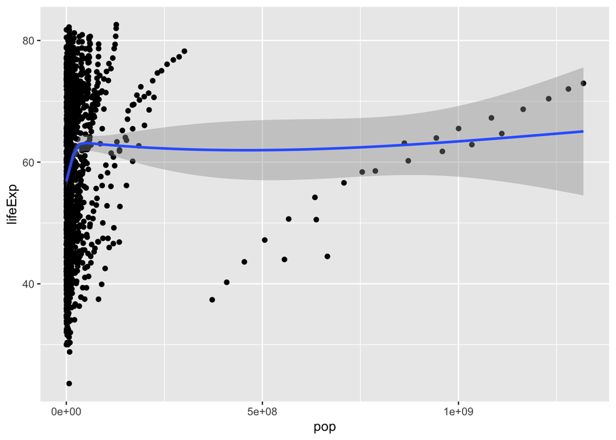

```r
# place appropriate r syntaxes to draw part b plot
p <- ggplot(data = gapminder,
            mapping = aes(x = pop,
                          y = lifeExp,))
p + geom_point() + geom_smooth()
```

- 3. Try some alternative scale mappings. Besides *scale_x_log 10()*, you can try *scale_x_sqrt()*

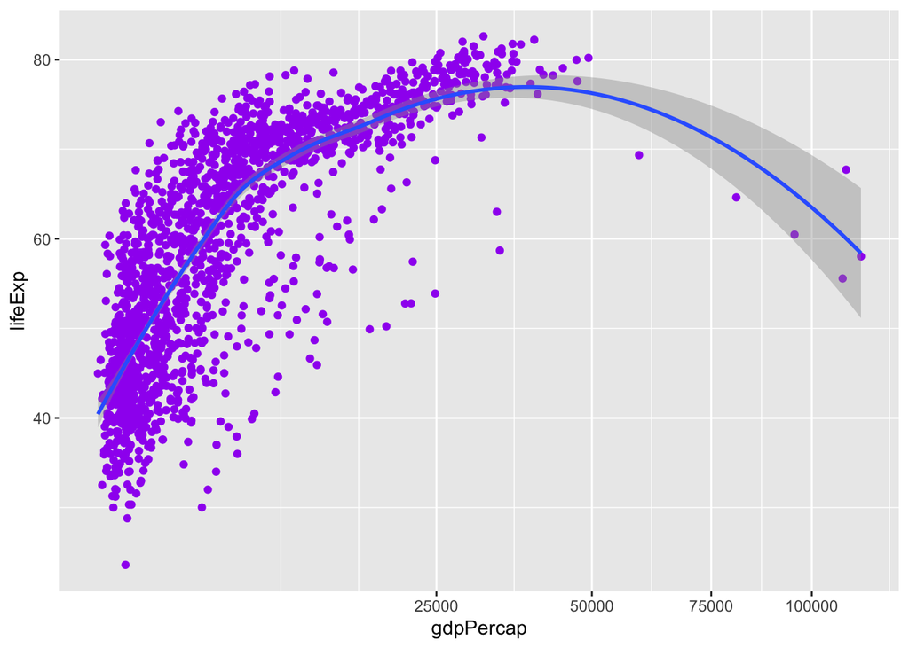

```r
# place appropriate r syntaxes to draw part c plot
p <- ggplot(data = gapminder,
            mapping = aes(x = gdpPercap,
                          y = lifeExp))
p + geom_point(color = "purple") +
  geom_smooth(method = "loess") +
  scale_x_sqrt()
```

- 4. What happens if you map *color* to year instead of *continent*? —Instead of many different colors, there are just different shades of blue representing different decades. There is also just one line through the data instead of the five, each representing a continent.

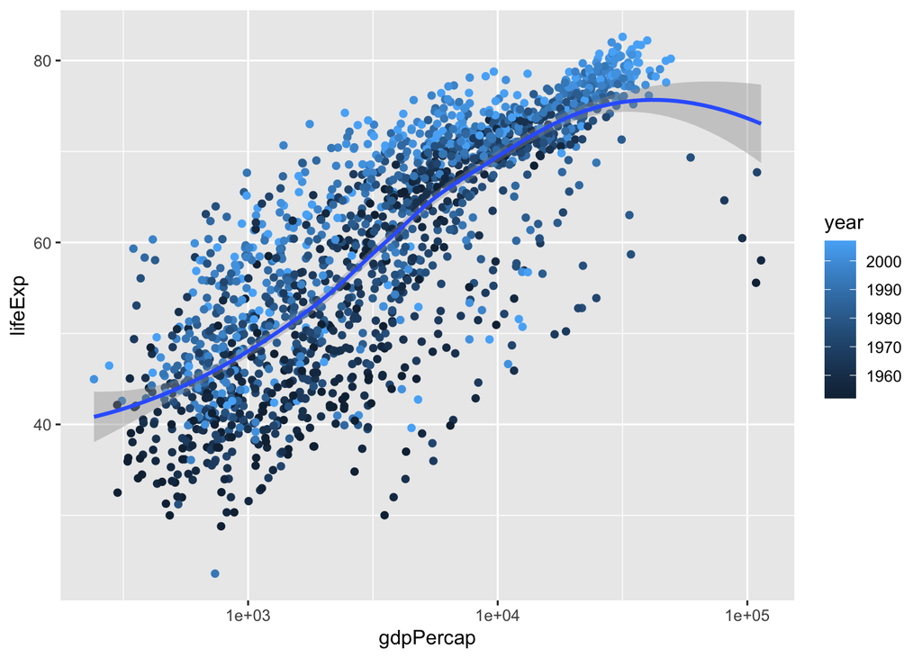

```r
# place appropriate r syntaxes to draw part d plot
p <- ggplot(data = gapminder,
            mapping = aes(x = gdpPercap,
                          y = lifeExp,
                          color = year))
p + geom_point() +
  geom_smooth(method = "loess") +
  scale_x_log10()
```

```r
gapminder
```

```
## # A tibble: 1,704 × 6
##    country     continent  year lifeExp      pop gdpPercap
##    <fct>       <fct>     <int>   <dbl>    <int>     <dbl>
##  1 Afghanistan Asia       1952    28.8  8425333      779.
##  2 Afghanistan Asia       1957    30.3  9240934      821.
##  3 Afghanistan Asia       1962    32.0 10267083      853.
##  4 Afghanistan Asia       1967    34.0 11537966      836.
##  5 Afghanistan Asia       1972    36.1 13079460      740.
##  6 Afghanistan Asia       1977    38.4 14880372      786.
##  7 Afghanistan Asia       1982    39.9 12881816      978.
##  8 Afghanistan Asia       1987    40.8 13867957      852.
##  9 Afghanistan Asia       1992    41.7 16317921      649.
## 10 Afghanistan Asia       1997    41.8 22227415      635.
## # … with 1,694 more rows
```

Is the result what you expected? Think about what class of object year is. Remember you can get a quick look at the top of the data, which includes some shorthand information on the class of each variable, by typing *gapminder.* —I wasn’t sure what to expect since “year” is an integer and “continent” is a factor.

- 5. Instead of mapping *color = year* in part d, what happens if you try *color = factor(year)*? There is now a different color representing each year in the dataset, rather than different shades of blue representing different decades, which I believe visualizes the data more effectively.

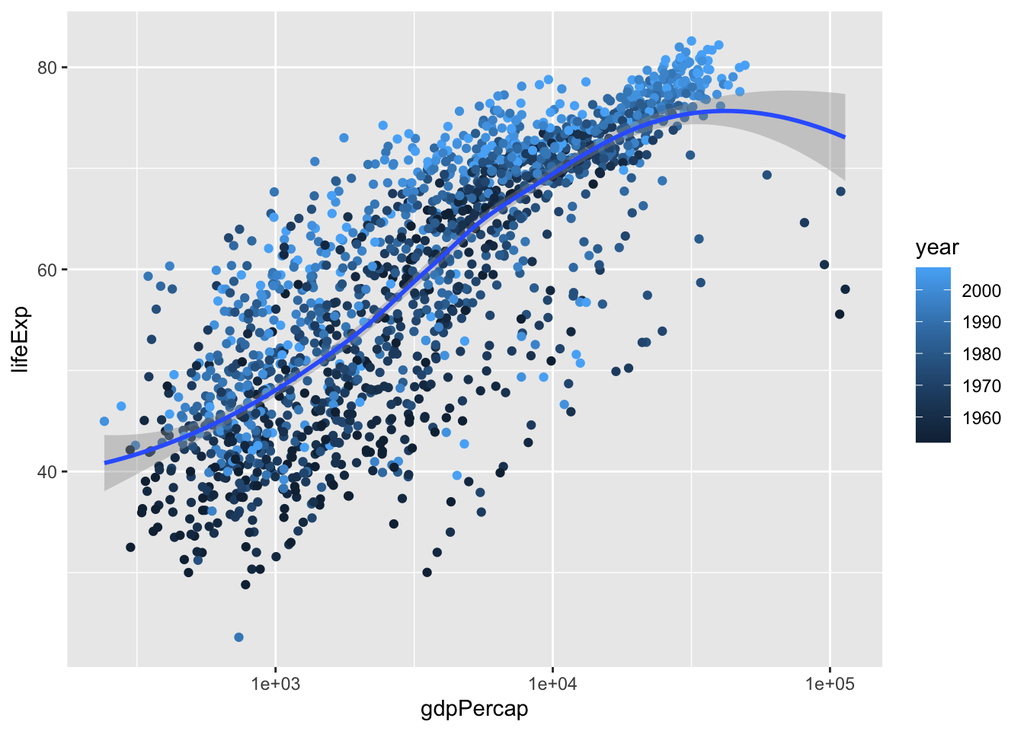

```r
# place appropriate r syntaxes to draw part e plot
p <- ggplot(data = gapminder,
            mapping = aes(x = gdpPercap,
                          y = lifeExp,
                          color = year))
p + geom_point() +
  geom_smooth(method = "loess") +
  scale_x_log10()
```

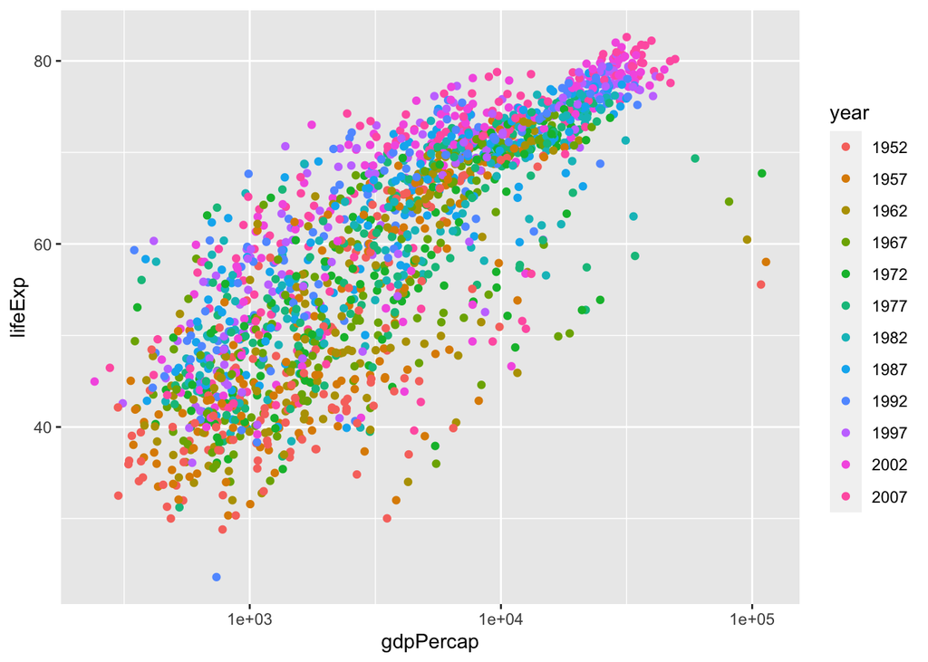

```r
p + geom_point(mapping = aes(color = factor(year))) +
  scale_x_log10()
```